# 16 Probeklausur

Schlüsselwörter

Statistik, Bayes, Wahrscheinlichkeit, Inferenz, R, Kausalität

Diese Liste ist im Aufbau. Bitte konsultieren Sie für weitere Aufgaben selbständig alle relevanten Aufgaben, die in den Kapiteln vorgestellt wurden.

## 16.1 2025

Hier finden Sie Single-Choice-Aufgaben zu einer Probeklausur aus dem Jahr 2025. Wählen Sie eine Antwort aus und klicken Sie auf das Häkchen, um sie zu überprüfen; über das Fragezeichen erhalten Sie die ausführliche Lösung.

Die Varianzanalyse (ANOVA) ist ein inferenzstatistisches Verfahren des Frequentismus. Welches Skalenniveau passt zu diesem Verfahren?

UV: nominal (mehrstufig), AV: metrischUV: nominal (zweistufig), AV: nominal (zweistufig)UV: metrisch, AV: metrischUV: nominal (mehrstufig), AV: nominal (mehrstufig)UV: metrisch, AV: nominal (zweistufig)

- Wahr
- Falsch
- Falsch
- Falsch
- Falsch

Wie viele Parameter sieht die folgende Definition eines Bayes-Modells vor?

$$\begin{aligned}
\text{y}_i &\sim \mathcal{N}(\mu_i,\sigma)\\
\mu_i &= \beta_0 + \beta_1\text{x1}_i + \beta_2\text{x2}_i \\
\beta_0, \beta_1, \beta_2 &\sim \mathcal{N}(0,2.5)\\
\sigma &\sim \mathcal{E}(1)
\end{aligned}$$

53624

Korrekt ist 4: Die Parameter sind $\beta_0, \beta_1, \beta_2$ (Regressionskoeffizienten) und $\sigma$ (Streuungsparameter).

- false
- false
- false
- false
- true

Die Inferenzstatistik ergänzt die deskriptive Statistik.

Welche Aussage zur Inferenzstatistik ist *FALSCH*?

Grund für die Schwankungen der Modellparameter zwischen den (zufällig gezogenen) Stichproben ist die Zufälligkeit des Stichprobenziehens.Die Inferenzstatistik verallgemeinert die Stichprobendaten auf eine Population.Kennzahlen einer Population nennt man auch Parameter.Man kann die Zielarten der Statistik in drei Gruppen fassen: Beschreiben, Vorhersagen und Zusammenfassen.Ein inferenzstatistisches Modells besitzt die folgenden zwei Arten von Ungewissheit: 1) Ungewissheit zu den Koeffizienten und 2) Ungewissheit zur Modellspezifikation.

Korrekt (d. h. die FALSCHE Aussage) ist diese Option: Die Zielarten der Statistik (insgesamt) werden üblicherweise nicht als Beschreiben, Vorhersagen und Zusammenfassen eingeteilt.

- Nein, wahr
- Nein, wahr
- Nein, wahr
- Ja, falsch
- Nein, wahr

Welche der folgenden Formeln stellt das Bayes-Theorem korrekt dar?

$Pr(H|D) = \dfrac{Pr(H) \times Pr(D)}{Pr(D|H)}$$Pr(H|D) = \dfrac{Pr(D|H)}{Pr(H) \times Pr(D)}$$Pr(H|D) = Pr(D|H) \times Pr(H) \times Pr(D)$$Pr(H|D) = Pr(H) + Pr(D|H) - Pr(D)$$Pr(H|D) = \dfrac{Pr(D|H) \times Pr(H)}{Pr(D)}$

Die Expontentialverteilung ist eine häufig verwendete Verteilung in der Statistik. Sie kann verwendet werden, um Streuungen zu modellieren.

Welche der folgenden Aussagen zur Exponentialverteilung ist **nicht** korrekt?

Die Exponentialverteilung hat nur einen Parameter.Die Exponentialverteilung ist streng monoton fallend.Die Exponentialverteilung ist symmetrisch.Die Exponentialverteilung ist eine stetige Verteilung.Die Exponentialverteilung ist nur für nicht-negative Werte definiert.

Richtig ist: Die Exponentialverteilung ist **nicht** symmetrisch (sie ist rechtsschief). Alle anderen Aussagen treffen zu: Sie ist stetig, nur für nicht-negative Werte definiert, hat nur den einen Parameter $\lambda$, und ist streng monoton fallend.

- False
- False
- True
- False
- False

Welche Definition von Statistik passt am besten?

Statistik fasst Daten zusammen.Statistik fasst Daten zusammen, um wesentliche Informationen den Daten zu entnehmen.Statistik vervielfacht Daten.Keine der genannten.Statistik fasst Daten zusammen, um wesentliche Informationen den Daten zu entnehmen und beschreibt die Ungewissheit unserer Schlüsse.

S. Skript

- False
- False
- False
- False
- True

Behauptung: *Ist Null nicht im Konfidenzintervall enthalten, so liegt ein statistisch signifikantes Ergebnis vor.*

Beziehen Sie sich auf die Lehrmeinung, wie im Skript dargestellt.

*Wählen Sie die korrekte Antwort!*

Die Behauptung ist richtig für die Bayes-Statistik, aber nicht für die Frequentistische Statistik.Die Behauptung ist richtig für die Frequentistische Statistik, aber nicht für die Bayes-Statistik.Die Behauptung ist nicht definiert.Die Behauptung ist richtig sowohl für die Bayes-Statistik als auch für die Frequentistische Statistik.Die Behauptung ist falsch für die Bayes-Statistik und für die Frequentistische Statistik.

Es gilt die Definition aus dem Unterricht: Der Zusammenhang zwischen dem (Nicht-)Enthaltensein der Null im Intervall und statistischer Signifikanz gilt in dieser Form nur für die Bayes-Statistik, nicht für die Frequentistische Statistik.

- True
- False
- False
- False
- False

Sei $X \sim \text{Exp}(1)$.

Welche der Aussagen ist richtig?

Die Verteilung hat keinen Mittelwert.Keine der genannten Antworten ist richtig.Je größer lambda, desto größer der Mittelwert der Verteilung.Je größer lambda, desto kleiner der Mittelwert der Verteilung.Lambda ist unabhängig vom Mittelwert der Verteilung.

Der Erwartungswert der Exponentialverteilung ist $E(X) = 1/\lambda$. Je größer $\lambda$, desto kleiner also der Mittelwert der Verteilung.

- False
- False
- False
- True
- False

Gegeben sei

$x \sim \text{Exp}(1)$.

Gesucht ist folgendes Quantil: 95 %.

Nutzen Sie die Tabelle der Exponentialverteilung, um das Quantil zu bestimmen.

| rate | 2.5 % | 5 % | 50 % | 95 % | 97.5 % |
| --- | --- | --- | --- | --- | --- |
| 1.00 | 0.03 | 0.05 | 0.69 | 3.00 | 3.69 |
| 2.00 | 0.01 | 0.03 | 0.35 | 1.50 | 1.84 |
| 4.00 | 0.01 | 0.01 | 0.17 | 0.75 | 0.92 |
| 8.00 | 0.00 | 0.01 | 0.09 | 0.37 | 0.46 |
| 0.50 | 0.05 | 0.10 | 1.39 | 5.99 | 7.38 |
| 0.25 | 0.10 | 0.21 | 2.77 | 11.98 | 14.76 |
| 0.12 | 0.20 | 0.41 | 5.55 | 23.97 | 29.51 |

1.503.003.695.990.69

Das 95 % Quantil der Exponentialverteilung mit $\lambda = 1$ beträgt 3.

Die Distraktoren entstehen durch typische Ablesefehler in der Tabelle: 3.69 (falsche Spalte, 97.5 % statt 95 %), 1.50 (falsche Zeile, rate = 2 statt rate = 1), 5.99 (falsche Zeile, rate = 0.5 statt rate = 1), 0.69 (falsche Spalte, 50 % statt 95 %).

- False
- True
- False
- False
- False

Prof. Süß-Sauer untersucht eine seiner Lieblingsfragen: Wie viel bringt das Lernen auf eine Klausur? Dabei konzentriert er sich auf das Fach Statistik (es gefällt ihm gut). In einer aktuellen Untersuchung hat er $n=70$ Studierende untersucht (s. Tabelle und Diagramm) und jeweils erfasst, ob die Person die Klausur bestanden ($B$) hat oder durchgefallen ($\neg B$) ist. Im Hinblick auf das Lernen, $L$ (wie viel die Person gelernt hat) hat er zwei Gruppen unterschieden: Die “Viel-Lerner” (VL) und die “Wenig-Lerner” (WL).

Das folgende Diagramm zeigt die Häufigkeiten pro Gruppe:

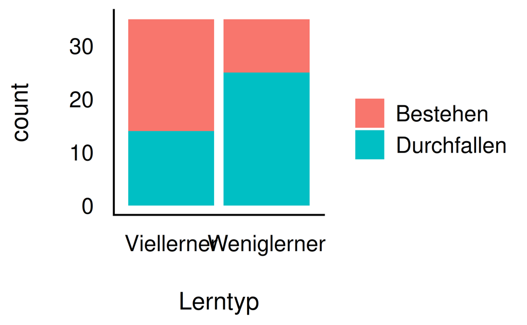

Hier ist die Kontingenztabelle mit den Häufigkeiten pro Gruppe:

| Lerntyp | Bestehen | Durchfallen |
| --- | --- | --- |
| Weniglerner | 10 | 25 |
| Viellerner | 21 | 14 |

*Berechnen Sie die folgende* gemeinsame Wahrscheinlichkeit*: p(Bestehen UND Weniglerner). Wählen Sie die richtige Antwortoption.*

0.860.360.140.290.3

Die gemeinsame Wahrscheinlichkeit berechnet sich als der Quotient der Zellenhäufigkeit und der Gesamthäufigkeit:

$Pr(Bestehen \cap Weniglerner) = \frac{n(Bestehen \cap Weniglerner)}{n_{gesamt}} = \frac{10}{70} = 0.14$

Die falschen Optionen entstehen durch typische Verwechslungen: die bedingte statt der gemeinsamen Wahrscheinlichkeit, die gemeinsame Wahrscheinlichkeit des jeweils anderen Klausurergebnisses bzw. der anderen Lerngruppe, sowie das naive Komplement (1 − Lösung).

- False
- False
- True
- False
- False

Ein renommiertes Unternehmen sucht einen Kandidaten für eine (hoch dotierte) Führungsposition. Ein Managementberatungsunternehmung führt ein Assessmentcenter durch, welches pro Kandidat/in eine positive bzw. negative Empfehlung ergibt. Aus früheren Erfahrungen heraus wissen die Berater, dass die tatsächlich geeigneten Kandidaten (Ereignis $E$ wie *eligible*) mit $60\%$ eine positive Empfehlung für die Stelle ausgesprochen bekommen (Ereignis $R$ wie *recommendation*). Weiterhin bekommen von den *nicht* geeigneten Kandidaten $72\%$ eine negative Empfehlung. Insgesamt wissen die Berater, dass $10\%$ der Bewerber/innen tatsächlich geeignet sind.

**Aufgabe:** Was ist die entsprechende Häufigkeitstabelle? Wählen Sie die Antwortoption, die alle vier gemeinsamen Wahrscheinlichkeiten (in Prozent) korrekt angibt.

*Hinweis*: Das Gegenereignis vom Ereignis $A$ wird als Komplementärereignis oder kurz als Komplement bezeichnet und mit $A^C$ oder $\overline{A}$ abgekürzt. Im vorliegenden Fall meint $\overline{R}=R^C$ das Ereignis, dass ein Kandidat *keine* Empfehlung ausgesprochen bekommt.

$P(E \cap R) = 4.00\%$, $P(\overline{E} \cap R) = 64.80\%$, $P(E \cap \overline{R}) = 6.00\%$, $P(\overline{E} \cap \overline{R}) = 25.20\%$$P(E \cap R) = 6.00\%$, $P(\overline{E} \cap R) = 25.20\%$, $P(E \cap \overline{R}) = 4.00\%$, $P(\overline{E} \cap \overline{R}) = 64.80\%$$P(E \cap R) = 25.20\%$, $P(\overline{E} \cap R) = 6.00\%$, $P(E \cap \overline{R}) = 64.80\%$, $P(\overline{E} \cap \overline{R}) = 4.00\%$$P(E \cap R) = 64.80\%$, $P(\overline{E} \cap R) = 4.00\%$, $P(E \cap \overline{R}) = 25.20\%$, $P(\overline{E} \cap \overline{R}) = 6.00\%$0

Einige Wahrscheinlichkeiten lassen sich direkt aus dem Text errechnen:

$$\begin{aligned}
P(E \cap R) & =
P(R | E) \cdot P(E) = 0.6 \cdot 0.1 = 0.06 = 6\%\\
P(\overline{E} \cap \overline{R}) & =
P(\overline{R} | \overline{E}) \cdot P(\overline{E}) = 0.72 \cdot 0.9 = 0.65 = 64.8\%.
\end{aligned}$$

Die restlichen gemeinsamen Wahrscheinlichkeiten lassen sich durch Addieren und Subtrahieren in der Kontingenztabelle errechnen:

|  | $R$ | $\overline{R}$ | Summe |
| --- | --- | --- | --- |
| $E$ | **6.00** | *4.00* | **10.00** |
| $\overline{E}$ | *25.20* | **64.80** | *90.00* |
| Summe | *31.20* | *68.80* | **100.00** |

Die falschen Antwortoptionen entstehen durch vertauschte Zeilen und/oder Spalten der Kontingenztafel (Verwechslung von $E$/$\overline{E}$ bzw. $R$/$\overline{R}$).

- False
- True
- False
- False
- False

Betrachten wir das Zufallsexperiment, bei dem ein Würfel geworfen wird. Wir haben keinen Grund zu glauben, dass eine bestimmte Augenzahl bevorzugt wird, und nehmen daher an, dass alle Augenzahlen gleich wahrscheinlich sind.

Sei $A$ das Ereignis, dass eine gerade Zahl geworfen wird. Sei $B$ das Ereignis, dass eine Zahl größer als 3 geworfen wird.

Was ist die Wahrscheinlichkeit für das Ereignis $A \cap B$, also das gemeinsame Eintreten von $A$ und $B$?

$\frac{1}{3}$$\frac{1}{2}$$\frac{1}{6}$$\frac{2}{3}$$\frac{1}{4}$

```
a <- c(2, 4, 6)
b <- c(4, 5, 6)

intersect(a, b)
## [1] 4 6
```

Die Schnittmenge von $A$ und $B$ ist also $\{4,6\}$, also die Menge der geraden Zahlen, die größer als 3 sind. Das sind 2 von 6 möglichen Ergebnissen, also ist die Wahrscheinlichkeit $P(A \cap B) = \frac{2}{6} = \frac{1}{3}$.

Die Distraktoren entstehen durch typische Fehler: $\frac{2}{3}$ (Vereinigung $A \cup B$ statt Schnitt), $\frac{1}{2}$ (nur Einzelereignis $A$ bzw. $B$), $\frac{1}{6}$ (Schnittmenge fälschlich als einelementig angenommen), $\frac{1}{4}$ (naive Multiplikation $P(A) \cdot P(B)$ unter der falschen Annahme der Unabhängigkeit).

- True
- False
- False
- False
- False

Wissenschaft! Vielleicht das wichtigste Projekt der Menschheit, geht es doch um die Loslöung von “Du musst das glauben, weil ich es sage” hin zu “Ich glaube das, weil ich es verstehe”.

Sei 1 % aller Studien der Wissenschaft “genial”. Ein Gutachter prüft eine wissenschaftliche Studie und erkennt 90 % der genialen Studien als solche. Allerdings stuft der Gutachter auch 10 % der nicht-genialen Studien fälschlich als genial ein. Nach der Prüfung der Studie ist der Gutachter überzeugt, dass die Studie genial ist.

*Aufgabe*: Berechnen Sie die Wahrscheinlichkeit, dass die Studie wirklich genial ist.

0.080.10.90.010.92

Gegeben ist:

```
Pr_g
## [1] 0.01
```

```
Pr_t_geg_g
## [1] 0.9
```

Hier kann man Bayes’ Theorem anwenden:

$Pr(g|t) = \frac{Pr(g) \cdot Pr(t|g) }{Pr(t)}$.

Zähler: 0.01

Nenner: 0.11

Bruch: 0.08

Die Lösung beträgt also: 0.08.

Hier ist ein Baumdiagramm zur Visualisierung:

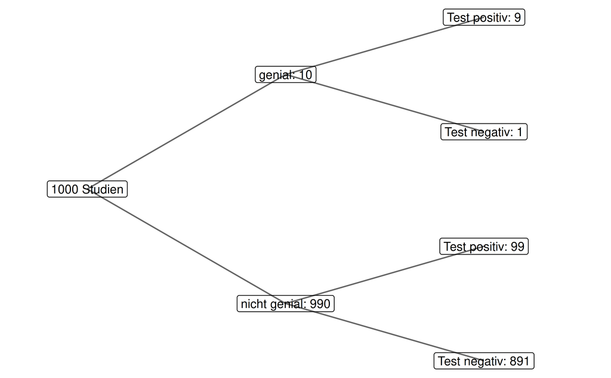

Es erhalten 108=99+9 Studien ein positives Testergebnis: “geniale Studie!” Davon sind 9 tatsächlich genial. Das ist ist ein Anteil von $\frac{9}{108} = 0.0833$.

Also: $Pr(g|t) = \frac{9}{108} = 0.0833$.

Alternativ kann man auch mit der Bayesbox arbeiten:

[output not shown]

Die Likelihood für die Hypothese $g$ (die Hypothese, dass die Studie genial ist) ist definiert als $Pr(D|H)=.9$. Hier entspricht der positive Genialitätstest den Daten.

Die unstandardisierte Post-Wahrscheinlichkeit entspricht dem Produkt aus Likelihood und Prior: $Pr(D|H) \cdot Pr(H)=.009$ bzw. $.099$.

Die Post-Wahrscheinlichkeit ist die durch die Evidenz dividierte unstandardisierte Post-Wahrscheinlichkeit: $Pr(H|D)= .009 / .108 = .083$ (bzw. für “nicht-genial”: $.917$).

Die Distraktoren entstehen durch typische Bayes-Fehler: Verwechslung mit der Likelihood $Pr(t|g)=0.9$ (Base-Rate-Neglect), Verwechslung mit dem Prior $Pr(g)=0.01$, das Komplement $1-Pr(g|t)$, sowie die falsch-positiv-Rate $1-Pr(t|g)=0.1$.

- True
- False
- False
- False
- False

Wir werfen einen Globus $n=9$ Mal und erzielen $W=9$ mal das Ereignis “Wasser”.

Was ist die Wahrscheinlichkeit dieses Ereignisses, wenn wir von einer Wasseranteil, d. h. Wahrscheinlichkeit, von $\pi=.7$ ausgehen?

0.040.960.140.7

Gegeben sind die Werte $W=9$, $n=9$, $\pi=0.7$. Wir suchen also diese Größe:

$$Pr(W=9 | \pi=0.7, n=9) = ?$$

Wir können R die Arbeit machen lassen:

```
dbinom(x = W, size = n, prob = pi)
## [1] 0.04
```

Oder den Taschenrechner nutzen:

```
choose(n,W) * pi^W * (1-pi)^(n-W)
## [1] 0.04
```

Die Harten unter uns rechnen es per Hand aus. Dafür kann man zunächst die Anzahl der Pfade mit dem Binomialkoeffizienten berechnen:

```
anzahl_pfade <- factorial(n) / (factorial(W) * factorial(n-W))
anzahl_pfade
## [1] 1
```

`factorial(W)` liefert die Fakultät von $W$ zurück.

Dann berechnet man die Wahrscheinlichkeit eines einzelnen Pfades:

```
pfad_wskt <-  pi^W * (1-pi)^(n-W)
pfad_wskt
## [1] 0.04
```

Multipliziert man die beiden vorherigen Zwischenergebnisse, so erhält man die Lösung: 0.04.

Die Distraktoren entstehen durch typische Fehler: $\pi$ direkt als Antwort verwendet (ohne Potenzieren), das Komplement $1 - Pr(W=9)$, sowie die falsche Basis $(1-\pi)^W$ (Wasseranteil und Gegenanteil vertauscht).

Die “.14” ist ein willkürlicher Distraktor.

- True
- False
- False
- False
- False

Für Statistiken (Stichprobe) verwendet man meist lateinische Buchstaben; für Parameter (Population) verwendet man meist (die entsprechenden) griechischen Buchstaben.

| Kennwert | Statistik | Parameter |
| --- | --- | --- |
| Mittelwert | $\bar{X}$ | NA |
| Mittelwertsdifferenz | $\bar{X}_1-\bar{X}_2$ | NA |
| Streuung | sd | NA |
| Anteil | p | NA |
| Korrelation | r | NA |
| Regressionsgewicht | b | NA |

*Welche Antwortoption vervollständigt folgende Tabelle korrekt?*

Mittelwert: $\sigma$, Mittelwertsdifferenz: $\mu_1-\mu_2$, Streuung: $\mu$, Anteil: $\pi$, Korrelation: $\beta$, Regressionsgewicht: $\rho$Mittelwert: $\mu$, Mittelwertsdifferenz: $\mu_1-\mu_2$, Streuung: $\sigma$, Anteil: $\pi$, Korrelation: $\beta$, Regressionsgewicht: $\rho$Mittelwert: $\mu$, Mittelwertsdifferenz: $\mu_1-\mu_2$, Streuung: $\sigma$, Anteil: $\pi$, Korrelation: $\rho$, Regressionsgewicht: $\beta$Mittelwert: $\mu$, Mittelwertsdifferenz: $\mu_1-\mu_2$, Streuung: $\pi$, Anteil: $\sigma$, Korrelation: $\rho$, Regressionsgewicht: $\beta$Mittelwert: $\sigma$, Mittelwertsdifferenz: $\mu_1-\mu_2$, Streuung: $\mu$, Anteil: $\pi$, Korrelation: $\rho$, Regressionsgewicht: $\beta$

Die korrekte Zuordnung von Statistik (Stichprobenkennwert) zu Parameter (Populationskennwert) lautet:

| Kennwert | Statistik | Parameter |
| --- | --- | --- |
| Mittelwert | $$\bar{X}$$ | $$\mu$$ |
| Mittelwertsdifferenz | $$d=\bar{X}_1-\bar{X}_2$$ | $$\mu_1$$ - $$\mu_2$$ |
| Streuung | sd | $$\sigma$$ |
| Anteil | p | $$\pi$$ |
| Korrelation | r | $$\rho$$ |
| Regressionsgewicht | b | $$\beta$$ |

Die falschen Optionen entstehen durch typische Verwechslungen: Streuung ($\sigma$) und Anteil ($\pi$) vertauscht, Korrelation ($\rho$) und Regressionsgewicht ($\beta$) vertauscht, sowie Mittelwert ($\mu$) und Streuung ($\sigma$) vertauscht.

- False
- False
- True
- False
- False

Übersetzen Sie folgende Forschungsfrage in die korrekte Regressionsformel!

*Gibt es einen Interaktionseffekt zwischen Geschlecht und Schnabellänge auf das Gewicht eines Pinguins? Liegen auch Haupteffekte vor?*

Welche Regressionsformel ist korrekt?

`body_mass_g ~ sex:bill_length_mm``body_mass_g ~ sex * bill_length_mm * species``body_mass_g ~ sex + bill_length_mm``body_mass_g ~ sex + bill_length_mm + species:bill_length_mm``body_mass_g ~ sex + bill_length_mm + sex:bill_length_mm`

Die Regressionsformel lautet: `body_mass_g ~ sex + bill_length_mm + sex:bill_length_mm`. Sie enthält beide Haupteffekte (`sex`, `bill_length_mm`) sowie den Interaktionsterm (`sex:bill_length_mm`) und hat `body_mass_g` korrekt als abhängige Variable.

- False
- False
- False
- False
- True

Betrachten Sie folgende Forschungsformel:

> Gibt es einen Interaktionseffekt zwischen Geschlecht und Schnabellänge auf das Gewicht eines Pinguins? Liegen auch Haupteffekte vor?

Auf Basis der folgenden Analyse ist folgende Frage zu untersuchen. Liegt ein Interaktionseffekt vor?

Zur besseren Interpretierbarkeit sind die metrischen UV standardisiert:

```
penguins_z <- standardize(penguins, select = c(bill_length_mm), append = TRUE)
```

Es werden verschiedene Modelle berechnet, die sich in ihrer Regressionsformel unterscheiden:

```
m1 <- stan_glm(body_mass_g ~ sex, data = penguins_z)
m2 <- stan_glm(body_mass_g ~ sex + bill_length_mm_z, data = penguins_z)
m3 <- stan_glm(body_mass_g ~ sex + bill_length_mm_z + sex:bill_length_mm_z,
               data = penguins_z)
m4 <- stan_glm(body_mass_g ~ sex:bill_length_mm_z, data = penguins_z)
m5 <- stan_glm(bill_length_mm_z ~ sex + body_mass_g + sex:body_mass_g, data = penguins_z)
```

Hier sind die Modellparameter (Punktschätzer als Median sowie 95 %-ETI):

| Modell | Median | CI_low | CI_high |
| --- | --- | --- | --- |
| m1 | 3864 | 3753 | 3978 |
| m2 | 4003 | 3907 | 4100 |
| m3 | 4012 | 3908 | 4116 |
| m4 | 4220 | 4144 | 4296 |
| m5 | 26 | 22 | 30 |

*Welches Modell ist korrekt spezifiziert, um die Forschungsfrage (Interaktionseffekt und Haupteffekte) zu beantworten?*

`m2`: `body_mass_g ~ sex + bill_length_mm_z``m5`: `bill_length_mm_z ~ sex + body_mass_g + sex:body_mass_g``m1`: `body_mass_g ~ sex``m3`: `body_mass_g ~ sex + bill_length_mm_z + sex:bill_length_mm_z``m4`: `body_mass_g ~ sex:bill_length_mm_z`

Die Regressionsformel lautet: `body_mass_g ~ sex + bill_length_mm_z + sex:bill_length_mm_z`. Daher ist `m3` korrekt, da sie beide Haupteffekte (`sex`, `bill_length_mm`) sowie den Interaktionsterm enthält.

- False
- False
- False
- True
- False

Beurteilen Sie folgende Aussagen: *Man kann die Forschungsfrage, ob sich zwei Gruppen (Populationen) hinsichtlich ihres Mittelwerts unterscheiden, mit einem t-Test oder einer Regressionsanalyse untersuchen.*

Wählen Sie die korrekte Antwortoption!

Ja, beide Verfahren sind analog, aber die Regression hat Vorzüge.Nein, eine Regression setzt intervallskalierte Prädiktoren voraus, daher ist sie hier nicht anwendbar.Nein, eine Regression kann nur bei mehr als zwei Gruppen verwendet werden.Nein, man sollte die Regression generell nicht verwenden.Ja, aber die Regression ist numerisch instabil und sollte daher nicht verwendet werden.

- True
- False
- False
- False
- False

Welche der folgenden Aussagen zur Interpretation eines Populationsparameters (z. B. $\mu$) eines Konfidenzintervalls der Art `95% CI [182cm; 184cm]` ist richtig bzw. passt am besten?

> Mit 95 % Wahrscheinlichkeit liegt der wahre Wert des zugrundeliegenden Parameters zwischen 182 cm und 184 cm.

Bedeutet, dass 95 % aller Messwerte der Population zwischen 182 cm und 184 cm liegenPasst weder zur Frequentistischen, noch zur Bayesianischen StatistikPasst nur zur Bayesianischen, nicht zur Frequentistischen StatistikPasst nur zur Frequentistischen, nicht zur Bayesianischen StatistikPasst sowohl zur Frequentistischen, als auch zur Bayesianischen Statistik

Passt nur zur Bayesianischen, nicht zur Frequentistischen Statistik.

- False
- False
- True
- False
- False

Betrachten Sie dieses Modell, das den Zusammenhang von PS-Zahl (`hp`: horse power) und Spritverbrauch (`mpg`: miles per Gallone) untersucht (Datensatz `mtcars`):

```
data(mtcars)
library(rstanarm)
library(easystats)
lm1 <- stan_glm(mpg ~ hp, data = mtcars,
                refresh = 0)
```

| Parameter | Median | 95% CI |
| --- | --- | --- |
| (Intercept) | 30.11 | (26.89, 33.43) |
| hp | -0.07 | (-0.09, -0.05) |

*Wie ist der Effekt von $\beta_1$ (hp) im Modell am besten zu interpretieren?*

Die Korrelation zwischen PS-Zahl und Spritverbrauch beträgt 0,1Der PS-Wert erklärt 0,1 % der Varianz im SpritverbrauchEin Auto mit einem PS mehr verbraucht 0,1 Gallonen mehr Sprit pro gefahrener MeileBei einem PS-Wert von 0 beträgt der geschätzte mittlere Spritverbrauch 0,1 Meilen pro GalloneEin Auto mit einem PS mehr kommt im Mittel ca. 0,1 (0.07) Meilen weniger weit mit einer Gallone Sprit, laut diesem Modell

*hp* ($\beta_1$) ist der Regressionskoeffizient und gibt den statistischen “Effekt” der PS-Zahl auf den Spritverbrauch an. Vorsicht: Dieser “Effekt” darf nicht vorschnell als kausaler Effekt verstanden werden. Vorsichtiger wäre zu sagen: “Ein Auto mit einem PS mehr, kommt im Mittel 0,1 (0.07) Meilen weniger weit mit einer Gallone Sprit, laut diesem Modell.” Den Punktschätzer des Regressionskoeffizienten kann man in der Parametertabelle in der Spalte `Median` auslesen.

Die Regressionsformel lautet: `mpg ~ hp`.

- False
- False
- False
- False
- True

Weltsensation?! Der Insektenforscher Prof. Mügge ist der Meinung, eine bislang unbekannte Käferart entdeckt zu haben. Nach nur 18 Jahren Feldforschung im brasilianischen Regenwald gelang ihm dieser Durchbruch. Wenn es denn nun wirklich eine neue Art ist. Gerade untersucht er ein Exemplar unter dem Mikroskop. Hm, was ist das für ein Tier?

Drei Arten kommen in Frage, $A_1, A_2, A_3$.

Dabei ist die Art $A_1$ sehr verbreitet und schon längst bekannt, $A_2$ ist die neue Art, Exemplare dieser Art sind selten und $A_3$ ist auch bekannt und eher häufig anzutreffen. Allerdings spricht das Aussehen am ehesten für $A_2$, der seltenen Art.

Hier sind die genauen Vorkommenshäufigkeiten:

```
Pr_A1 <- .6
Pr_A2 <- .1
Pr_A3 <- .3
```

Und hier die genauen Wahrscheinlichkeiten, wie typisch das beobachtete Objekt für einen Vertreter der jeweiligen Art ist:

```
L_A1 <- .5
L_A2 <- .9
L_A3 <- .4
```

*Wie groß ist die Wahrscheinlichkeit, dass Prof. Mügge wirklich einen großen Fang gemacht hat und einen unbekannten Käfer entdeckt hat?* Berechnen Sie diese Wahrscheinlichkeit!

50 %17,6 %23,1 %10 %90 %

```
library(tidyverse)
library(prada)  # für Funktion `bayesbox`

bb <- bayesbox(hyps = c("A", "B", "C"),
               priors = c(Pr_A1, Pr_A2, Pr_A3),
               liks = c(L_A1, L_A2, L_A3))

bb
```

| hyps | priors | liks | post_unstand | post_std |
| --- | --- | --- | --- | --- |
| A | 0.6 | 0.5 | 0.30 | 0.59 |
| B | 0.1 | 0.9 | 0.09 | 0.18 |
| C | 0.3 | 0.4 | 0.12 | 0.24 |

Die Wahrscheinlichkeit, dass der Käfer zur Art “B” (also $A_2$) gehört, ist relativ klein: 17,6 %. Man erhält sie durch Anwendung des Satzes von Bayes: Prior × Likelihood, normiert durch die Summe aller Prior × Likelihood-Produkte: $(.1 \times .9) / (.6\times.5 + .1\times.9 + .3\times.4) = .09/.51 = .176$.

- False
- True
- False
- False
- False

In *Think Bayes* stellt Allen Downey folgende Aufgabe:

“Angenommen, es gibt zwei Schüsseln mit Keksen.

Schüssel 1 enthält 30 Vanillekekse und 10 Schokoladenkekse.

Schüssel 2 enthält 20 Vanillekekse und 20 Schokoladenkekse.

Nehmen Sie nun an, Sie wählen zufällig eine der beiden Schüsseln aus und ziehen daraus, ohne hinzusehen, zufällig einen Keks.

*Wenn der Keks Vanille ist, wie groß ist die Wahrscheinlichkeit, dass er aus Schüssel 1 stammt?*”

*Wählen Sie die korrekte Antwort!*

.33.40.75.50.60

```
library(tidyverse)

d <-
  tibble(
    p_Gitter = c(1, 2),
    Priori  = .5) %>%
    mutate(
      Likelihood = c(3/4, 2/4),
      unstd_Post = Likelihood * Priori,
      Evidenz = sum(unstd_Post),
      Post = unstd_Post / sum(unstd_Post))

d %>%
  knitr::kable(digits=2)
```

| p_Gitter | Priori | Likelihood | unstd_Post | Evidenz | Post |
| --- | --- | --- | --- | --- | --- |
| 1 | 0.5 | 0.75 | 0.38 | 0.62 | 0.6 |
| 2 | 0.5 | 0.50 | 0.25 | 0.62 | 0.4 |

Die Antwort lautet **.60**. Es ist übrigens egal, ob Sie für die Priori-Werte .5 oder 1 (oder eine andere Zahl) wählen, solange Sie für alle Hypothesen die gleiche Zahl verwenden – das Ergebnis bleibt dann gleich.

- False
- False
- False
- False
- True

Eine Studentin hat zwei Klausuren, $A$ und $B$ geschrieben. Sie schätzt ihre Chancen zu bestehen auf 35 % bzw. auf 60 %. Unterstellen Sie Unabhängigkeit der Ereignisse.

```
Pr_A <- .35
Pr_B <- .6
```

*Wie groß ist die Chance, mindestens eine der beiden Klausuren zu bestehen?*

26 %74 %95 %60 %21 %

Es gibt mehrere Wege, die Aufgabe zu lösen: die direkte Berechnung, die Gegenwahrscheinlichkeit (1 minus die Wahrscheinlichkeit, beide durchzufallen), oder über den Additionssatz ($Pr_A + Pr_B - Pr_{AB}$).

```
Pr_A <- .35
Pr_B <- .6
Pr_AB <- Pr_A * Pr_B
Pr_mind1_bestanden <- 1 - (1 - Pr_A) * (1 - Pr_B)
Pr_mind1_bestanden
## [1] 0.74
```

Die Lösung lautet **74 %**.

Die Distrkatoren sind willkürlich gewählt.

- False
- True
- False
- False
- False

Ein Krebstest ($T$) hat die Wahrscheinlichkeit 0.9, einen vorhandenen Krebs ($K$) zu erkennen: $Pr(T+|K+)$. Die Falsch-Positiv-Rate beträgt 0.05: $Pr(T+|K-)$. Die Grundrate dieser Krebsart liegt bei 0.01: $Pr(K+)$.

Berechnen Sie die Wahrscheinlichkeit, dass ein Patient tatsächlich Krebs hat, wenn der Test positiv ist: $Pr(K+|T+)$.

0.170.180.010.850.15

$$Pr(K+|T+) = \frac{Pr(T+|K+) \cdot Pr(K+)}{Pr(T+|K+) \cdot Pr(K+) + Pr(T+|K-) \cdot Pr(K-)} = \frac{0.9 \cdot 0.01}{0.9 \cdot 0.01 + 0.05 \cdot 0.99} = 0.15$$

- Falsch
- Falsch
- Falsch
- Falsch
- Wahr

## 16.2 2024

1. [ttest-als-regr](https://sebastiansauer.github.io/datenwerk/posts/ttest-als-regr/ttest-als-regr.html)
2. [Additionssatz1](https://sebastiansauer.github.io/datenwerk/posts/additionssatz1/additionssatz1)
3. [Nerd-gelockert](https://sebastiansauer.github.io/datenwerk/posts/nerd-gelockert/nerd-gelockert)
4. [Urne1](https://sebastiansauer.github.io/datenwerk/posts/urne1/urne1)
5. [corona-blutgruppe](https://sebastiansauer.github.io/datenwerk/posts/corona-blutgruppe/corona-blutgruppe.html)
6. [voll-normal](https://sebastiansauer.github.io/datenwerk/posts/voll-normal/index.html)
7. [alphafehler-inflation3](https://sebastiansauer.github.io/datenwerk/posts/alphafehler-inflation3/alphafehler-inflation3.html)
8. verteilungen-quiz-05
9. verteilungen-quiz-03
10. verteilungen-quiz-04
11. [Kekse03](https://sebastiansauer.github.io/datenwerk/posts/kekse03/index.html)
12. [globus-bin2](https://sebastiansauer.github.io/datenwerk/posts/globus-bin2/)
13. [globus2](https://sebastiansauer.github.io/datenwerk/posts/globus2/)
14. [iq01a](https://sebastiansauer.github.io/datenwerk/posts/iq01a/)
15. [gem-wskt4](https://sebastiansauer.github.io/datenwerk/posts/gem-wskt4/)
16. [Rethink2m3](https://sebastiansauer.github.io/datenwerk/posts/rethink2m3/rethink2m3)
17. [mtcars-post2a](https://sebastiansauer.github.io/datenwerk/posts/mtcars-post2a/)
18. [groesse03](https://sebastiansauer.github.io/datenwerk/posts/groesse03/)
19. [bath42](https://sebastiansauer.github.io/datenwerk/posts/bath42/bath42.html)
20. klausur-raten
21. bed-post-wskt1
22. [mtcars-post3a](https://sebastiansauer.github.io/datenwerk/posts/mtcars-post3a/)
23. [exp-tab](https://sebastiansauer.github.io/datenwerk/posts/exp-tab/)
24. [norms-sd](https://sebastiansauer.github.io/datenwerk/posts/norms-sd/)
25. [mtcars-post_paper](https://sebastiansauer.github.io/datenwerk/posts/mtcars-post_paper/)
26. [bfi10](https://sebastiansauer.github.io/datenwerk/posts/bfi10/)
27. [rope-luecke](https://sebastiansauer.github.io/datenwerk/posts/rope-luecke/)
28. [wskt-schluckspecht2a](https://sebastiansauer.github.io/datenwerk/posts/wskt-schluckspecht2a/)
29. [penguins-stan-06](https://sebastiansauer.github.io/datenwerk/posts/penguins-stan-06/index.html)

## 16.3 2023

[Dieser Tag auf dem Datenwerk](https://sebastiansauer.github.io/datenwerk/#category=qm2-pruefung) stellt Fragen einer Probeprüfung (Version 2023) zusammen.

## 16.4 2022

[Dieser Tag auf dem Datenwerk](https://sebastiansauer.github.io/datenwerk/#category=exam-22) stellt Fragen einer Probeprüfung (Version 2022) zusammen.